# Clean & Analyze Social Media

## Introduction

Social media has become a ubiquitous part of modern life, with platforms such as Instagram, Twitter, and Facebook serving as essential communication channels. Social media data sets are vast and complex, making analysis a challenging task for businesses and researchers alike. In this project, we explore a simulated social media, for example Tweets, data set to understand trends in likes across different categories.

## Prerequisites

To follow along with this project, you should have a basic understanding of Python programming and data analysis concepts. In addition, you may want to use the following packages in your Python environment:

- pandas
- Matplotlib
- ...

These packages should already be installed in Coursera's Jupyter Notebook environment, however if you'd like to install additional packages that are not included in this environment or are working off platform you can install additional packages using `!pip install packagename` within a notebook cell such as:

- `!pip install pandas`
- `!pip install matplotlib`

## Project Scope

The objective of this project is to analyze tweets (or other social media data) and gain insights into user engagement. We will explore the data set using visualization techniques to understand the distribution of likes across different categories. Finally, we will analyze the data to draw conclusions about the most popular categories and the overall engagement on the platform.

## Step 1: Importing Required Libraries

As the name suggests, the first step is to import all the necessary libraries that will be used in the project. In this case, we need pandas, numpy, matplotlib, seaborn, and random libraries.

Pandas is a library used for data manipulation and analysis. Numpy is a library used for numerical computations. Matplotlib is a library used for data visualization. Seaborn is a library used for statistical data visualization. Random is a library used to generate random numbers.

```python
# Importing libraries
import pandas as pd
import numpy as np
import seaborn as sns
import matplotlib.pyplot as plt
import random
```

## Step 2: Generating random data for the social media data

Now we need to generate some random tweet data to analyze. We use pandas date range to choose a pseudo-random date within a range, the random module’s choice to create a choice from a list, and numpy’s random to create a random integer

```python
# generate radom data
categories= ["Food", "Travel", "Fashion", "Fitness","Music", "Culture", "Family","Health"]
data = {'Date': pd.date_range('2021-01-01', periods=1000),
       'Category': [random.choice(categories) for _ in range(1000)],
       'Likes': np.random.randint(0, 10000, size=1000)}
```

## Step 3: Loading the data into a pandas DataFrame and Exploring the data

The next step is to load the randomly generated data into the pandas dataframe and print the data.

```python
df= pd.DataFrame(data)
df.head(10)
```

|  | Date | Category | Likes |
| --- | --- | --- | --- |
| 0 | 2021-01-01 | Fashion | 6316 |
| 1 | 2021-01-02 | Culture | 9815 |
| 2 | 2021-01-03 | Travel | 3253 |
| 3 | 2021-01-04 | Health | 4867 |
| 4 | 2021-01-05 | Fitness | 2700 |
| 5 | 2021-01-06 | Culture | 4753 |
| 6 | 2021-01-07 | Food | 5781 |
| 7 | 2021-01-08 | Health | 4784 |
| 8 | 2021-01-09 | Family | 7969 |
| 9 | 2021-01-10 | Travel | 7806 |

```python
df.info()
```

```
<class 'pandas.core.frame.DataFrame'>
RangeIndex: 1000 entries, 0 to 999
Data columns (total 3 columns):
 #   Column    Non-Null Count  Dtype
---  ------    --------------  -----
 0   Date      1000 non-null   datetime64[ns]
 1   Category  1000 non-null   object
 2   Likes     1000 non-null   int64
dtypes: datetime64[ns](1), int64(1), object(1)
memory usage: 23.6+ KB
```

- There are three columns and 1000 rows in this dataframe.

```python
df.describe()
```

|  | Likes |
| --- | --- |
| count | 1000.000000 |
| mean | 4909.292000 |
| std | 2867.417954 |
| min | 30.000000 |
| 25% | 2407.000000 |
| 50% | 4870.000000 |
| 75% | 7484.500000 |
| max | 9990.000000 |

```python
df['Category'].value_counts()
```

```
Food       140
Music      139
Family     135
Culture    134
Health     124
Fashion    113
Travel     110
Fitness    105
Name: Category, dtype: int64
```

## Step 4: Cleaning the data

An important aspect of processing data is to move invalid data points so you can effectively perform statistics and visualize valid data. The pandas dataframe has built-in functionality to clean the data

```python
# Check for missing data
df.isna().any().sum()
```

```
0
```

- No missing data in this data frame

```python
# Check for duplicate data
df.duplicated().sum()
```

```
0
```

- No duplicate data

```python
df.dtypes
```

```
Date        datetime64[ns]
Category            object
Likes                int64
dtype: object
```

## Step 5: Visualize and Analyse Data

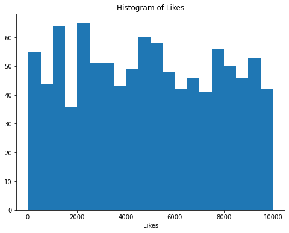

```python
# Plot histogram for "Likes"
plt.figure(figsize=(8,6))
plt.hist(data=df, x='Likes', bins=20)
plt.title("Histogram of Likes")
plt.xlabel("Likes")
plt.show()
```

- This graph show a almost a uniform ditribution. No chance of outliers

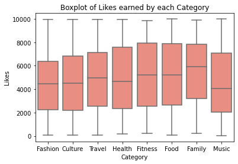

```python
# plot boxplot to check outliers
plt.figure(figsize= (6,4))
sns.boxplot(data= df, x= "Category",y="Likes", color= "salmon")
plt.title("Boxplot of Likes earned by each Category")
plt.show()
```

No ouliers present in this data. Median of all columns are between 4000 and 6000.

```python
# calculate the mean for each categories likes using groupby method
df_mean= df.groupby(['Category']).mean()[['Likes']].reset_index()
df_mean
```

|  | Category | Likes |
| --- | --- | --- |
| 0 | Culture | 4679.283582 |
| 1 | Family | 5427.340741 |
| 2 | Fashion | 4504.176991 |
| 3 | Fitness | 5218.495238 |
| 4 | Food | 5262.278571 |
| 5 | Health | 4825.411290 |
| 6 | Music | 4496.043165 |
| 7 | Travel | 4842.209091 |

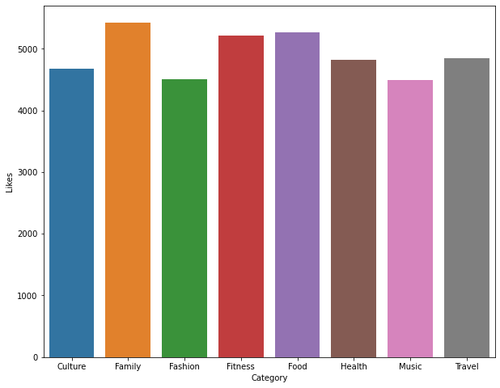

```python
# plot the mean value of categories in barplot
plt.figure(figsize=(10,8))
sns.barplot(data= df_mean,x="Category", y="Likes")
```

- The graph demonstrates a relatively consistent number of likes across all categories, with the Family category receiving the highest engagement. Fitness and Food categories secure the second-highest position in terms of audience interaction.

## Step 6: Conclusion

- The dataframe comprises 1000 rows and three columns, with datatypes datetime64, int64, and object. The data was found to be clean, devoid of missing values, erroneous entries, outliers, or duplicates. The histogram reveals a near-uniform distribution of the data.
- A bar chart analysis indicates a relatively even distribution of likes across categories, with the Family category slightly outperforming others. Fitness and Food categories share the second position in terms of likes, while Fashion and Music lag comparatively.
- The data suggests that all topics hold a degree of significance within the social media platform, indicating potential engagement opportunities across various interest areas.